# Advanced Statistical Methods HW3

2021-21116 Taeyoung Chang

10/3/2021

### Exercise 4.2

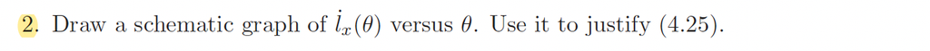

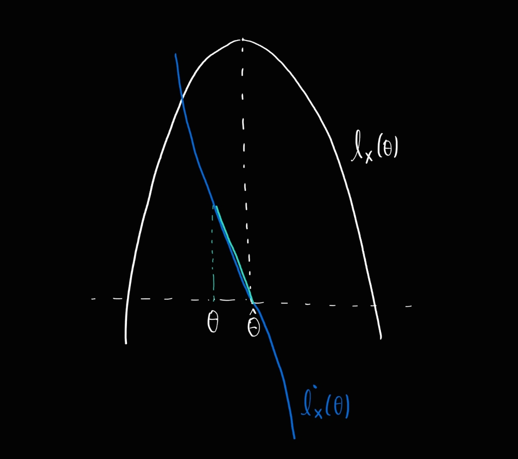

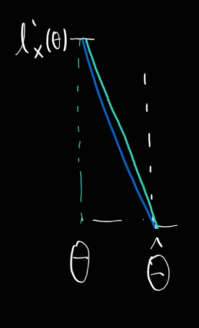

Since loglikelihood $l_x(\theta)$ is typically concave, we can draw a schematic graph of $l_x(\theta)$ as a concave function of $\theta$ which has a maximum value at $\theta=\hat\theta^{MLE}$. Near $\hat\theta^{MLE}$, $\dot{l}_x(\theta)$ has positive value at $\theta<\hat\theta^{MLE}$, negaive value at $\theta>\hat\theta^{MLE}$, and zero value at $\theta=\hat\theta^{MLE}$ as drawn in the first figure. Now, from the second figure, we can justify (4.25)
$$\hat\theta^{MLE}\dot{=}\;\theta+\frac{\dot {l}_x(\theta)}{-\ddot{l}_x(\theta)}$$
The slope of $\dot{l}_x(\theta)$ is $\ddot{l}_x(\theta)$, which can be approximated by
$$\ddot{l}_x(\theta)\dot{=}\;\frac{\dot{l}_x(\theta)}{\theta-\hat\theta^{MLE}} \quad \because \; \dot{l}_x(\hat\theta^{MLE})=0$$
By multiplying $\theta-\hat\theta^{MLE}$ and dividing by $\ddot{l}_x(\theta)$ on both sides, we get the desired result.

### Exercise 4.3

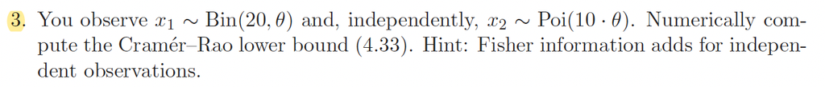

let $x=(x_1, x_2)$ .
$$I(\theta)=E\Big[\big(\frac{\partial}{\partial\theta}\log f(x;\theta)\big)^2 \Big]=-E\Big[\frac{\partial^2}{\partial\theta^2}\log f(x;\theta) \Big]=-E\Big[\frac{\partial^2}{\partial\theta^2}\log f(x_1;\theta) \Big]-E\Big[\frac{\partial^2}{\partial\theta^2}\log f(x_2;\theta) \Big] \quad \because\; x_1, x_2\quad independent$$

We can analytically derive a closed form of $I(\theta)$ and Cramer-Rao lower bound which is $I(\theta)^{-1}$

$$\begin{align*}
f(x_1;\theta)&=\binom{20}{x_1}\theta^{x_1}(1-\theta)^{20-x_1} \\
\log f(x_1;\theta)&= \log\binom{20}{x_1}+x_1\log\theta+(20-x_1)\log(1-\theta) \\
\frac{\partial}{\partial\theta}\log f(x_1;\theta)&=\frac{x_1}{\theta}-\frac{20-x_1}{1-\theta} \\
\frac{\partial^2}{\partial\theta^2}\log f(x_1;\theta)&=-\frac{x_1}{\theta^2}-\frac{20-x_1}{(1-\theta)^2} \\
-E\Big[\frac{\partial^2}{\partial\theta^2}\log f(x_1;\theta) \Big]&=\frac{20\theta}{\theta^2}+\frac{20(1-\theta)}{(1-\theta)^2}=\frac{20}{\theta(1-\theta)}\\
f(x_2;\theta)&=\frac{e^{-10\theta}(10\theta)^{x_2}}{x_2!} \\
\log f(x_2;\theta)&= -10\theta+x_2\log(10\theta)-\log x_2! \\
\frac{\partial}{\partial\theta}\log f(x_2;\theta)&=-10 +\frac{x_2}{\theta} \\
\frac{\partial^2}{\partial\theta^2}\log f(x_2;\theta)&=-\frac{x_2}{\theta^2}\\
-E\Big[\frac{\partial^2}{\partial\theta^2}\log f(x_1;\theta) \Big]&=\frac{10\theta}{\theta^2}=\frac{10}{\theta}
\end{align*}$$
Hence we have
$$I(\theta)= \frac{20}{\theta(1-\theta)}+\frac{10}{\theta}=\frac{10(3-\theta)}{\theta(1-\theta)} \\ CRLB(\theta)=\frac{1}{I(\theta)}=\frac{\theta(1-\theta)}{10(3-\theta)}$$

Now we have to numerically compute CRLB given observed data $x_1$ and $x_2$. We shall find $\hat\theta^{MLE}$ and then CRLB can be computed as $CRLB(\hat\theta^{MLE})$ or $1/I(x)$ where
$$I(x)= -\frac{\partial^2}{\partial\theta^2}\log f(x;\theta) \Big|_{\theta=\hat\theta^{MLE}} =-\Big(-\frac{x_1}{\theta^2}-\frac{20-x_1}{(1-\theta)^2}-\frac{x_2}{\theta^2}\Big)\;\Big|_{\theta=\hat\theta^{MLE}}=\frac{x_1+x_2}{\theta^2}+\frac{20-x_1}{(1-\theta)^2}\;\Big |_{\theta=\hat\theta^{MLE}}$$
is an observed Fisher information.
We shall now consider an algorithm to find $\hat\theta^{MLE}$ numerically.
$$\begin{align*}
\dot{l}_x(\theta)&=\frac{x_1}{\theta}-\frac{20-x_1}{1-\theta}-10 +\frac{x_2}{\theta}=\frac{x_1+x_2}{\theta}-\frac{20-x_1}{1-\theta}-10 \\
\ddot{l}_x(\theta)&=-\frac{x_1+x_2}{\theta^2}-\frac{20-x_1}{(1-\theta)^2}<0\quad \;\forall\;0<\theta<1 \\
\dot{l}_x(\theta)&=0 \Leftrightarrow (1-\theta)(x_1+x_2)-\theta(20-x_1)-10\theta(1-\theta)=0\Leftrightarrow 10\theta^2-(30+x_2)\theta+(x_1+x_2)=0
\end{align*}$$
Define a function $g$ by
$$g(\theta)=10\theta^2-(30+x_2)\theta+(x_1+x_2)=10\Big(\theta-\frac{30+x_2}{20} \Big)^2+constant$$

Note that $\dot{l}_x(\theta)=0\Leftrightarrow g(\theta)=0$ on $\theta\in (0,1)$. Hence, if we can find a solution $\theta\in(0,1)$ of $g(\theta)=0$, then it is a solution of likelihood equation so that it is $\hat\theta^{MLE}$. Note that since $\frac{30+x_2}{20}>1.5$, by the shape of $g$, $g(\theta)=0$ must have a root bigger than 1.5 , which implies that we should guide the algorithm to do not find a solution outside of desired area $(0,1)$.  
Here we can show an algorithm to find $\hat\theta^{MLE}$. To generate a sample $x_1, x_2$, we set a true value of $\theta$ as $0.7$. To find a solution $\theta$ in $(0,1)$, we shall use Dekker’s method which is a combination of bisection method and secant method.

```r
theta=0.7

set.seed(100)
x1=rbinom(1, size=20, prob=theta)
x2=rpois(1, lambda=10*theta)
print(c(x1, x2))
```

```
## [1] 15  5
```

```r
# error tolerance value for terminating the alogirthm
tol=1e-8

# function g defined above
g=function(theta, x1, x2){
  10*theta^2-(30+x2)*theta+(x1+x2)
}

library(seqinr) # To use 'swap' function

mix_mle<-function(x1,x2, tol){
  # Starting value of [a,b] for the method is [0,1]
  # Note that g(0)=x1+x2 and g(1)=x1-20 so that g(0)>=0 and g(1)<=0
  # This satisfies the starting condition for bisection method
  a=0
  theta.past=a
  theta.current=1
  while(TRUE){
    # g'(theta) is replaced by this ratio, which is a strategy of the secant method
    ratio = (g(theta.current, x1,x2)-g(theta.past, x1,x2)) / (theta.current-theta.past)
    # middle point of the current step [a,b]
    middle=(a + theta.current)/2
    # new theta value proposal by secant method
    proposal = ifelse(g(theta.current, x1,x2)-g(theta.past, x1,x2)!=0,  theta.current-g(theta.current, x1,x2) / ratio , middle)

    # new theta is determined to be the proposal value or the middle point
    if(middle<theta.current){
      theta.new=ifelse(proposal<=theta.current & proposal>=middle, proposal, middle)
    }
    else{
      theta.new=ifelse(proposal<=middle & proposal>=theta.current, proposal, middle)
    }
    # stops the alogorithm when |g(theta)| < error tolerance
    if(abs(g(theta.new,x1,x2))<tol ) break
    # Update value of [a,b] to satisfy condition necessary for the bisection method
    if(g(theta.new, x1, x2)*g(a, x1, x2)>0) a=theta.current
    # If a accidentally attains |g(a)|<|g(theta)| then swap a and theta
    if(abs(g(theta.new,x1,x2))>abs(g(a, x1,x2)) ) swap(a, theta.new)

    theta.past=theta.current
    theta.current=theta.new

  }
  return(theta.new)
}

theta.hat=mix_mle(x1, x2, tol)
theta.hat
```

```
## [1] 0.7192236
```

Hence, with $\theta=0.7$, the sample $x_1=15, \, x_2=5$ is generated. From this sample, we calculate $\hat\theta^{MLE}=0.71922$ which is quite close to the true value of $\theta$.

```r
RCLB.true=theta*(1-theta)/(10*(3-theta))
RCLB.plugin=theta.hat*(1-theta.hat)/(10*(3-theta.hat))
obsinfo=(x1+x2)/theta.hat^2+(20-x1)/(1-theta.hat)^2
RCLB.obsinfo=1/obsinfo
print(cbind(RCLB.true, RCLB.plugin, RCLB.obsinfo))
```

```
##        RCLB.true RCLB.plugin RCLB.obsinfo
## [1,] 0.009130435 0.008854047  0.009795578
```

We can check that `RCLB.plugin` and `RCLB.obsinfo`, which are the resulted computation for RCLB by our numerical method, are very close to the true value of Cramer Rao lower bound.